# DMR Annotation

Sarah Stucchi

Date: August 19, 2025

# 1. Environment setting

```r
library(DSS)
```

```r
library(plotly)
library(ggplot2)
library(scales)
library(gridExtra)
library(ChIPseeker)
library(org.Hs.eg.db)
library(ReactomePA)
## ReactomePA v1.42.0  For help: https://yulab-smu.top/biomedical-knowledge-mining-book/
##
## If you use ReactomePA in published research, please cite:
## Guangchuang Yu, Qing-Yu He. ReactomePA: an R/Bioconductor package for reactome pathway analysis and visualization. Molecular BioSystems 2016, 12(2):477-479
library(clusterProfiler)
## clusterProfiler v4.6.2  For help: https://yulab-smu.top/biomedical-knowledge-mining-book/
##
## If you use clusterProfiler in published research, please cite:
## T Wu, E Hu, S Xu, M Chen, P Guo, Z Dai, T Feng, L Zhou, W Tang, L Zhan, X Fu, S Liu, X Bo, and G Yu. clusterProfiler 4.0: A universal enrichment tool for interpreting omics data. The Innovation. 2021, 2(3):100141
##
## Attaching package: 'clusterProfiler'
## The following object is masked from 'package:AnnotationDbi':
##
##     select
## The following object is masked from 'package:IRanges':
##
##     slice
## The following object is masked from 'package:S4Vectors':
##
##     rename
## The following object is masked from 'package:stats':
##
##     filter
library(dmrseq)
library(annotatr)
library(DT)
library(data.table)
GTFFile <- "/group/testa/Project/PGCLC/NewData_fromLaSitua/3.TwistBedAnn/Input/gencode.v35.annotation.gtf.gz"
txdb_v35 <- GenomicFeatures::makeTxDbFromGFF(GTFFile, format="gtf")
## Import genomic features from the file as a GRanges object ...
## OK
## Prepare the 'metadata' data frame ... OK
## Make the TxDb object ...
## Warning in .get_cds_IDX(mcols0$type, mcols0$phase): The "phase" metadata column contains non-NA values for features of type
##   stop_codon. This information was ignored.
## OK
```

```r
InputFolder <- params$InputFolder
OutputFolder <- params$OutputFolder
```

# 2. Loading data

## 2.1 BSSeq objects

Loading of bsseq object, with CpGs shared by 75% of samples (after sample selection).

```r
bsseq_obj <- readRDS("/group/testa/Project/PGCLC/emseq_rebuttal/2.PreliminaryAnalysis/bsseq_obj_sharedby75ofall.rds") #getting bsseq object where sample selection and CpG filtering were already performed
```

## 2.2 DMRs and DMLs

**The DMRs here selected are called like this: `delta=0.25` and `p.threshold=0.0001`**

```r
DMRs <- readRDS(paste0(InputFolder, '/', 'DMRs.rds'))
#DMLs <- readRDS(paste0(InputFolder, '/', 'DMLs.rds'))
```

## 2.3 Universe of genes

Importing Twist regions that were annotated

```r
TwistAnnotated <- readRDS(params$TwistAnnotated)
TwistAnnotated %>% head()
```

```
##   seqnames start   end width strand
## 1     chr1 10466 10585   120      *
## 2     chr1 10790 10909   120      *
## 3     chr1 15806 15925   120      *
## 4     chr1 18768 18887   120      *
## 5     chr1 29357 29476   120      *
## 6     chr1 36544 36663   120      *
##                                                               ann
## 1                                            cg14817997,cpg_inter
## 2                                 cg16269199,cg26928153,cpg_inter
## 3 CTCF_binding_site,cg13869341,cpg_inter,promoter_flanking_region
## 4                                            cg14008030,cpg_inter
## 5                      cg12045430,cg20826792,cpg_islands,promoter
## 6                   cg18231760,cpg_inter,promoter_flanking_region
##         annotation geneChr geneStart geneEnd geneLength geneStrand
```

[output cut: 55 more lines]

```r
Genes_df <- TwistAnnotated[, c("ensembl_gene_id_version", "ensembl_gene_id", "hgnc_symbol", "gene_biotype")] %>% dplyr::distinct()%>%filter(!is.na(hgnc_symbol))%>%filter(!hgnc_symbol%in%"")
rownames(Genes_df) <- NULL
```

These are the genes with the same symbol but different ensembl id

```r
Genes_df[Genes_df$hgnc_symbol%in%Genes_df[duplicated(Genes_df$hgnc_symbol), "hgnc_symbol"],]
```

```
##       ensembl_gene_id_version ensembl_gene_id hgnc_symbol
## 3309        ENSG00000285053.1 ENSG00000285053        TBCE
## 3310        ENSG00000284770.2 ENSG00000284770        TBCE
## 20449       ENSG00000237940.3 ENSG00000237940   LINC01238
## 20451       ENSG00000261186.2 ENSG00000261186   LINC01238
## 21924      ENSG00000206195.11 ENSG00000206195      DUXAP8
## 21926       ENSG00000271672.1 ENSG00000271672      DUXAP8
## 24581       ENSG00000284862.3 ENSG00000284862      CCDC39
## 24582      ENSG00000145075.13 ENSG00000145075      CCDC39
## 30308       ENSG00000272655.2 ENSG00000272655     POLR2J4
## 30309       ENSG00000214783.9 ENSG00000214783     POLR2J4
##                             gene_biotype
## 3309                      protein_coding
## 3310                      protein_coding
## 20449                             lncRNA
## 20451                             lncRNA
## 21924                             lncRNA
## 21926   transcribed_processed_pseudogene
## 24581                     protein_coding
## 24582                             lncRNA
## 30308 transcribed_unprocessed_pseudogene
## 30309                             lncRNA
```

```r
Genes_df$entrez_gene_id <- as.vector(mapIds(org.Hs.eg.db, Genes_df$hgnc_symbol, "ENTREZID","SYMBOL"))
## 'select()' returned 1:many mapping between keys and columns
```

```r
nrow(Genes_df[is.na(Genes_df$entrez_gene_id),]) #number of genes without an entrez id
```

```
## [1] 421
```

```r
GeneUniverse_symbol <- unique(Genes_df$hgnc_symbol)
GeneUniverse_entrezid <- na.omit(unique(Genes_df$entrez_gene_id))
```

# 3. Transform DataFrame with DMRs info to GRanges object

Remember that position form bedGraph files are 0-based while R works with 1-based position and therefore also the packages we will go to use, this is the reason why I set `starts.in.df.are.0based = TRUE` in creating the GRanges objects, it converts 0-based to 1-based coordinates.

```r
DMRs_GRanges <- DMRs
#DMLs_GRanges <- DMLs

for(i in 1:length(DMRs)){
  DMRs_GRanges[[i]] <- makeGRangesFromDataFrame(DMRs_GRanges[[i]], keep.extra.columns = TRUE,
                                                start.field = "start", end.field = "end", starts.in.df.are.0based = TRUE)
#DMLs_GRanges[[i]] <- makeGRangesFromDataFrame(DMLs_GRanges[[i]], keep.extra.columns = TRUE,
  #start.field = "start", end.field = "end", starts.in.df.are.0based = TRUE)
  }
```

- For hiPSCs vs hEGCLC_p10 we have 125 DMRs.
- For iMeLCs vs hEGCLCs_p10 we have 267 DMRs.
- For hPGCLCs vs hEGCLC_p10 we have 3361 DMRs.
- For hEGCLCs_p5 vs hEGCLCs_p10 we have 770 DMRs.

# 4. DMRs annotation

## 4.1 hiPSCs vs hEGCLCs_p10

### 4.1.1 Genetic annotation and visualization with **`ChIPseeker`**

DMRs are now annotated to their associated genes and genomic regions using the `annotatePeaks` function of the `ChIPseeker`R package, using a TxDb object. The [`GenomicFeatures`](https://bioconductor.org/packages/devel/bioc/vignettes/GenomicFeatures/inst/doc/GenomicFeatures.html) package uses `TxDb` objects to store transcript metadata. This class maps the 5’ and 3’ untranslated regions (UTRs), protein coding sequences (CDSs) and exons for a set of mRNA transcripts to their associated genome. All `TxDb` objects are backed by a SQLite database that manages genomic locations and the relationships between pre-processed mRNA transcripts, exons, protein coding sequences, and their related gene identifiers.

**TxDb created by us**

```r
peakAnnoList <- lapply(list("Higher methylation in hiPSCs" = DMRs_GRanges$hEGCLCs_p10vshiPSCs[DMRs_GRanges$hEGCLCs_p10vshiPSCs$diff.Methy<0,], "Higher methylation in hEGCLCs_p10" = DMRs_GRanges$hEGCLCs_p10vshiPSCs[DMRs_GRanges$hEGCLCs_p10vshiPSCs$diff.Methy>0,]), annotatePeak, TxDb=txdb_v35, tssRegion=c(-3000, 3000), verbose=FALSE)
```

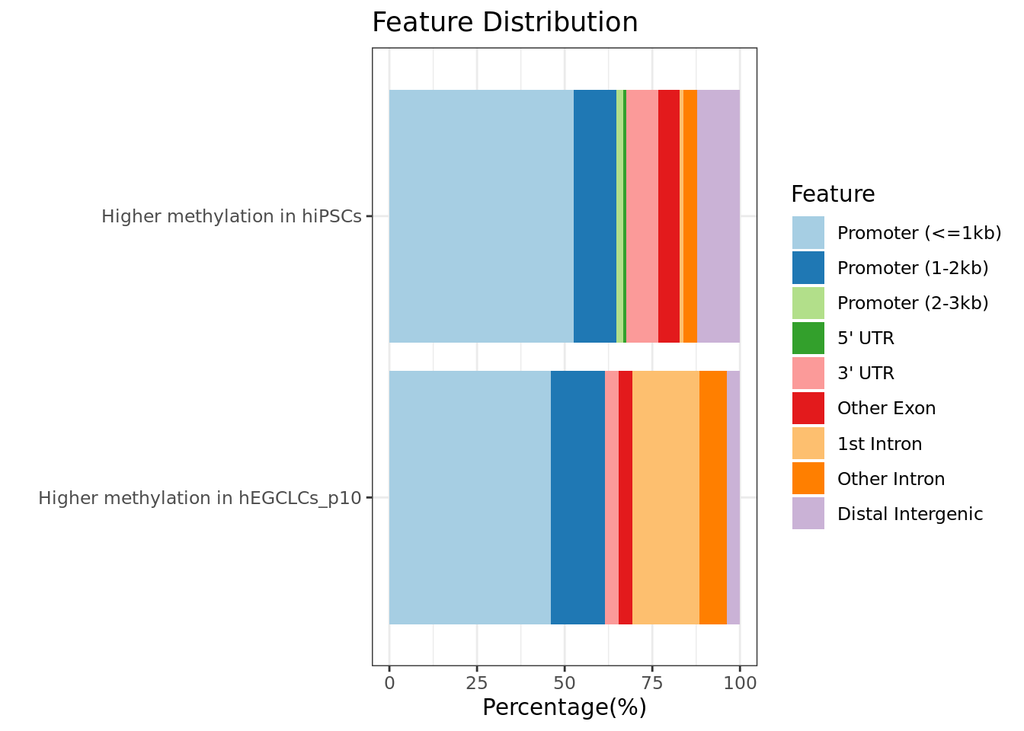

```r
ChIPseeker::plotAnnoBar(peakAnnoList)
```

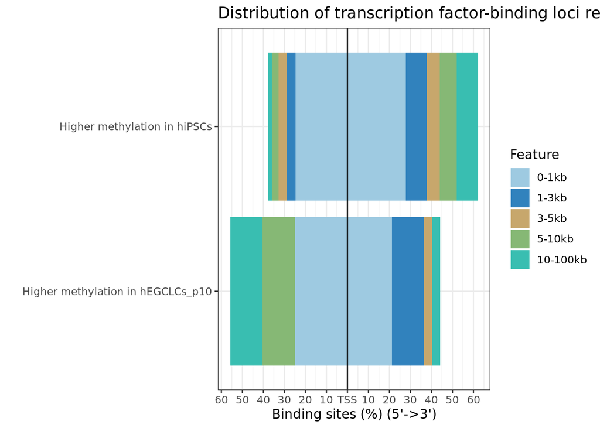

```r
ChIPseeker::plotDistToTSS(peakAnnoList)
```

Given a list of gene set, `compareCluster` function will compute profiles of each gene cluster.

```r
genes = lapply(peakAnnoList, function(i) unique(as.data.frame(i)$geneId))
names(genes) = sub("_", "\n", names(genes))
```

```r
any(duplicated(genes$`Higher methylation in hiPSCs`))
```

```
## [1] FALSE
```

```r
any(duplicated(genes$`Higher methylation in hEGCLCs_p10`))
```

```
## [1] FALSE
```

There are no duplicated ensembl ids

```r
table(genes$`Higher methylation in hEGCLCs_p10` %in% Genes_df$ensembl_gene_id_version)
## < table of extent 0 >
```

```r
genes$`Higher methylation in hEGCLCs_p10` [!genes$`Higher methylation in hEGCLCs_p10` %in% Genes_df$ensembl_gene_id_version]
## NULL
```

```r
table(genes$`Higher methylation in hiPSCs`%in% Genes_df$ensembl_gene_id_version)
```

```
##
## FALSE  TRUE
##    16    82
```

```r
DMG_uphiPSCsvshEGCLCs_p10 <- Genes_df[Genes_df$ensembl_gene_id_version %in% genes$`Higher methylation in hiPSCs`, "entrez_gene_id"]
DMG_uphiPSCsvshEGCLCs_p10 <- na.omit(DMG_uphiPSCsvshEGCLCs_p10[!DMG_uphiPSCsvshEGCLCs_p10 %in% ""])
DMG_downhiPSCsvshEGCLCs_p10 <- Genes_df[Genes_df$ensembl_gene_id_version %in% genes$`Higher methylation in hEGCLCs_p10`, "entrez_gene_id"]
DMG_downhiPSCsvshEGCLCs_p10 <- na.omit(DMG_downhiPSCsvshEGCLCs_p10[!DMG_downhiPSCsvshEGCLCs_p10 %in% ""])
```

```r
any(duplicated(DMG_uphiPSCsvshEGCLCs_p10))
```

```
## [1] FALSE
```

```r
any(duplicated(DMG_downhiPSCsvshEGCLCs_p10))
```

```
## [1] FALSE
```

```r
genes$`Higher methylation in hiPSCs` <- DMG_uphiPSCsvshEGCLCs_p10
genes$`Higher methylation in hEGCLCs_p10` <- DMG_downhiPSCsvshEGCLCs_p10
```

```r
compKEGG <- compareCluster(geneCluster   = genes,
                         fun           = "enrichKEGG",
                         organism="hsa",
                         pvalueCutoff  = 0.05,
                         pAdjustMethod = "BH",
                         universe = GeneUniverse_entrezid)
```

There are no significant terms (They have Padj>0.05)

```r
#dotplot(compKEGG, showCategory = 15, title = "KEGG Pathway Enrichment Analysis")
```

```r
compGO <- compareCluster(geneCluster   = genes,
                         fun           = "enrichGO",
                         keyType = "ENTREZID",
                         pvalueCutoff  = 0.05,
                         pAdjustMethod = "BH",
                         OrgDb='org.Hs.eg.db',
                         universe=GeneUniverse_entrezid,
                         ont = "ALL")
```

```r
#dotplot(compGO, showCategory = 15, title = "GO Enrichment Analysis")
```

A new `DMRs_annotated` object is created in which annotation from `ChIPseeker` is added.

```r
DMRs_annotated <- DMRs_GRanges

mcols(DMRs_annotated$hEGCLCs_p10vshiPSCs)$ChipSeekerAnn <- NA
mcols(DMRs_annotated$hEGCLCs_p10vshiPSCs)$ChipSeekerDistanceToTss <- NA
mcols(DMRs_annotated$hEGCLCs_p10vshiPSCs)$ChipSeekerGeneId <- NA

m <- findOverlaps(DMRs_annotated$hEGCLCs_p10vshiPSCs, peakAnnoList[["Higher methylation in hiPSCs"]]@anno)
mcols(DMRs_annotated$hEGCLCs_p10vshiPSCs)[queryHits(m), "ChipSeekerAnn"] <- mcols(peakAnnoList[["Higher methylation in hiPSCs"]]@anno)[subjectHits(m), "annotation"]
mcols(DMRs_annotated$hEGCLCs_p10vshiPSCs)[queryHits(m), "ChipSeekerDistanceToTss"] <- mcols(peakAnnoList[["Higher methylation in hiPSCs"]]@anno)[subjectHits(m), "distanceToTSS"]
mcols(DMRs_annotated$hEGCLCs_p10vshiPSCs)[queryHits(m), "ChipSeekerGeneId"] <- mcols(peakAnnoList[["Higher methylation in hiPSCs"]]@anno)[subjectHits(m), "geneId"]

m <- findOverlaps(DMRs_annotated$hEGCLCs_p10vshiPSCs, peakAnnoList[["Higher methylation in hEGCLCs_p10"]]@anno)
mcols(DMRs_annotated$hEGCLCs_p10vshiPSCs)[queryHits(m), "ChipSeekerAnn"] <- mcols(peakAnnoList[["Higher methylation in hEGCLCs_p10"]]@anno)[subjectHits(m), "annotation"]
mcols(DMRs_annotated$hEGCLCs_p10vshiPSCs)[queryHits(m), "ChipSeekerDistanceToTss"] <- mcols(peakAnnoList[["Higher methylation in hEGCLCs_p10"]]@anno)[subjectHits(m), "distanceToTSS"]
mcols(DMRs_annotated$hEGCLCs_p10vshiPSCs)[queryHits(m), "ChipSeekerGeneId"] <- mcols(peakAnnoList[["Higher methylation in hEGCLCs_p10"]]@anno)[subjectHits(m), "geneId"]
```

Adding entrez gene id, gene symbol and gene information

```r
DMRs_annotated$hEGCLCs_p10vshiPSCs <- as.data.frame(DMRs_annotated$hEGCLCs_p10vshiPSCs)
DMRs_annotated$hEGCLCs_p10vshiPSCs <- dplyr::left_join(DMRs_annotated$hEGCLCs_p10vshiPSCs, Genes_df, by=c('ChipSeekerGeneId' = 'ensembl_gene_id_version'))
```

```r
DMRs_annotated$hEGCLCs_p10vshiPSCs[!is.na(DMRs_annotated$hEGCLCs_p10vshiPSCs$hgnc_symbol),] %>% select(-c("ChipSeekerDistanceToTss", "ChipSeekerGeneId", "ensembl_gene_id", "entrez_gene_id")) %>% distinct() %>%
    datatable(class = 'hover', rownames = FALSE, caption="DMRs - hEGCLCs_p10vshiPSCs", extension='Buttons', escape = FALSE,
              options = list(pageLength=20, dom='Bfrtip', autoWidth=TRUE,
                             buttons=list(c('csv', 'excel'))))
```

| seqnames | start | end | width | strand | length | nCG | meanMethy1 | meanMethy2 | diff.Methy | areaStat | ChipSeekerAnn | hgnc_symbol | gene_biotype |
| --- | --- | --- | --- | --- | --- | --- | --- | --- | --- | --- | --- | --- | --- |
| chr8 | 38973776 | 38975246 | 1471 | * | 1472 | 97 | 0.1184031912607835 | 0.8502559401604043 | -0.7318527488996208 | -9414.875051619849 | Promoter (<=1kb) | HTRA4 | protein_coding |
| chr6 | 144007780 | 144008932 | 1153 | * | 1154 | 127 | 0.1859417471199258 | 0.5455076971360223 | -0.3595659500160965 | -8940.055192835376 | Promoter (<=1kb) | PLAGL1 | protein_coding |
| chr20 | 58853970 | 58856323 | 2354 | * | 2355 | 189 | 0.1553104448278889 | 0.5271022337744012 | -0.3717917889465124 | -5691.512822215524 | Promoter (<=1kb) | GNAS | protein_coding |
| chr11 | 64368176 | 64370713 | 2538 | * | 2539 | 155 | 0.3137232220291328 | 0.8668794131687677 | -0.553156191139635 | -5479.534362117779 | Promoter (<=1kb) | MIR1237 | miRNA |
| chr11 | 66568068 | 66568850 | 783 | * | 784 | 80 | 0.2774003822416267 | 0.7215172050123094 | -0.4441168227706827 | -4381.560935108409 | Promoter (<=1kb) | CTSF | protein_coding |
| chr5 | 172669729 | 172670381 | 653 | * | 654 | 89 | 0.2330072639060043 | 0.6551324669357276 | -0.4221252030297232 | -4033.272327056086 | Exon (ENST00000369800.6/ENSG00000214357.9, exon 2 of 5) | MIR5003 | miRNA |
| chr1 | 248847249 | 248848404 | 1156 | * | 1157 | 129 | 0.5081177299098374 | 0.9624178105511203 | -0.4543000806412829 | -3619.509187441728 | 5' UTR | ZNF692 | protein_coding |
| chrX | 145817894 | 145818886 | 993 | * | 994 | 100 | 0.8925733823529794 | 0.541332245352056 | 0.3512411370009234 | 3532.989540056729 | Promoter (<=1kb) | SLITRK2 | protein_coding |
| chr22 | 19941574 | 19942186 | 613 | * | 614 | 61 | 0.05478124779731025 | 0.3355542388602483 | -0.280772991062938 | -3497.238786991881 | Promoter (<=1kb) | COMT | protein_coding |
| chr5 | 491206 | 492041 | 836 | * | 837 | 67 | 0.7574401126143476 | 0.3479527655801739 | 0.4094873470341737 | 2948.370009908843 | Exon (ENST00000264938.8/ENSG00000066230.12, exon 2 of 17) | SLC9A3 | protein_coding |

[output cut: 96 more lines]

```r
saveRDS(DMRs_annotated, paste0(OutputFolder, '/', 'DMRsAnnotated1.rds'))
```

## 4.2 iMeLCs VS hEGCLC_p10

### 4.2.1 Genetic annotation and visualization with **`ChIPseeker`**

DMRs are now annotated to their associated genes and genomic regions using the `annotatePeaks` function of the `ChIPseeker`R package, using a TxDb object. The [`GenomicFeatures`](https://bioconductor.org/packages/devel/bioc/vignettes/GenomicFeatures/inst/doc/GenomicFeatures.html) package uses `TxDb` objects to store transcript metadata. This class maps the 5’ and 3’ untranslated regions (UTRs), protein coding sequences (CDSs) and exons for a set of mRNA transcripts to their associated genome. All `TxDb` objects are backed by a SQLite database that manages genomic locations and the relationships between pre-processed mRNA transcripts, exons, protein coding sequences, and their related gene identifiers.

**TxDb created by us**

```r
peakAnnoList <- lapply(list("Higher methylation in iMeLCs" = DMRs_GRanges$hEGCLCs_p10vsiMeLCs[DMRs_GRanges$hEGCLCs_p10vsiMeLCs$diff.Methy<0,], "Higher methylation in hEGCLCs_p10" = DMRs_GRanges$hEGCLCs_p10vsiMeLCs[DMRs_GRanges$hEGCLCs_p10vsiMeLCs$diff.Methy>0,]), annotatePeak, TxDb=txdb_v35, tssRegion=c(-3000, 3000), verbose=FALSE)
```

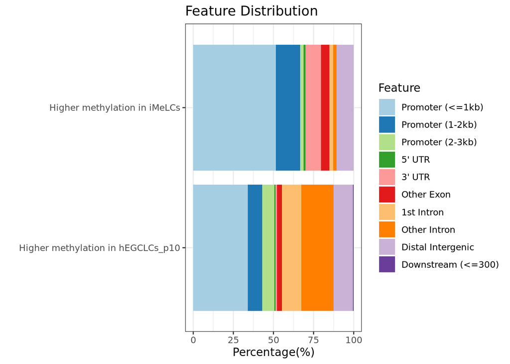

```r
ChIPseeker::plotAnnoBar(peakAnnoList)
```

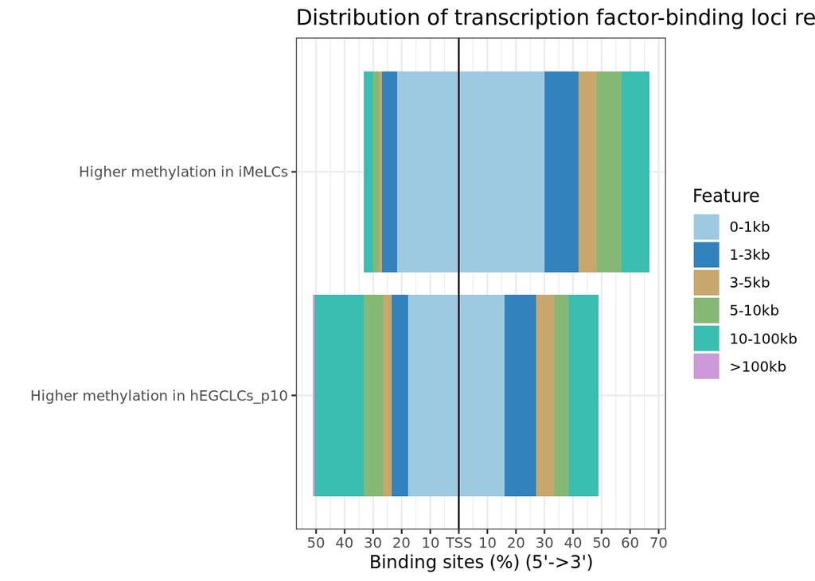

```r
ChIPseeker::plotDistToTSS(peakAnnoList)
```

Given a list of gene set, `compareCluster` function will compute profiles of each gene cluster.

```r
genes = lapply(peakAnnoList, function(i) unique(as.data.frame(i)$geneId))
names(genes) = sub("_", "\n", names(genes))
```

```r
any(duplicated(genes$`Higher methylation in hEGCLC_p10`))
```

```
## [1] FALSE
```

```r
any(duplicated(genes$`Higher methylation in iMeLCs`))
```

```
## [1] FALSE
```

There are no duplicated ensembl ids

```r
table(genes$`Higher methylation in iMeLCs` %in% Genes_df$ensembl_gene_id_version)
```

```
##
## FALSE  TRUE
##    17    73
```

```r
genes$`Higher methylation in iMeLCs` [!genes$`Higher methylation in iMeLCs` %in% Genes_df$ensembl_gene_id_version]
```

```
##  [1] "ENSG00000251196.1" "ENSG00000259607.1" "ENSG00000249149.2"
##  [4] "ENSG00000204850.4" "ENSG00000261842.1" "ENSG00000233820.2"
##  [7] "ENSG00000274219.1" "ENSG00000270889.1" "ENSG00000255108.1"
## [10] "ENSG00000288571.1" "ENSG00000267713.1" "ENSG00000275201.1"
## [13] "ENSG00000224765.1" "ENSG00000269388.1" "ENSG00000238110.1"
## [16] "ENSG00000274660.1" "ENSG00000227459.1"
```

```r
table(genes$`Higher methylation in hEGCLC_p10`%in% Genes_df$ensembl_gene_id_version)
## < table of extent 0 >
```

```r
DMG_uphEGCLCs_p10vsiMeLCs <- Genes_df[Genes_df$ensembl_gene_id_version %in% genes$`Higher methylation in hEGCLC_p10`, "entrez_gene_id"]
DMG_uphEGCLCs_p10vsiMeLCs <- na.omit(DMG_uphEGCLCs_p10vsiMeLCs[!DMG_uphEGCLCs_p10vsiMeLCs %in% ""])
DMG_downhEGCLCs_p10vsiMeLCs <- Genes_df[Genes_df$ensembl_gene_id_version %in% genes$`Higher methylation in iMeLCs`, "entrez_gene_id"]
DMG_downhEGCLCs_p10vsiMeLCs <- na.omit(DMG_downhEGCLCs_p10vsiMeLCs[!DMG_downhEGCLCs_p10vsiMeLCs %in% ""])
```

```r
any(duplicated(DMG_uphEGCLCs_p10vsiMeLCs))
```

```
## [1] FALSE
```

```r
any(duplicated(DMG_downhEGCLCs_p10vsiMeLCs))
```

```
## [1] FALSE
```

```r
genes$`Higher methylation in hEGCLC_p10` <- DMG_uphEGCLCs_p10vsiMeLCs
genes$`Higher methylation in iMeLCs` <- DMG_downhEGCLCs_p10vsiMeLCs
```

```r
compKEGG <- compareCluster(geneCluster   = genes,
                         fun           = "enrichKEGG",
                         organism="hsa",
                         pvalueCutoff  = 0.05,
                         pAdjustMethod = "BH",
                         universe = GeneUniverse_entrezid)
```

There are no significant terms (They have Padj>0.05)

```r
if (!is.null(compKEGG)) {
  dotplot(compKEGG, showCategory = 15, title = "KEGG Pathway Enrichment Analysis")
  }
```

```r
compGO <- compareCluster(geneCluster   = genes,
                         fun           = "enrichGO",
                         keyType = "ENTREZID",
                         pvalueCutoff  = 0.05,
                         pAdjustMethod = "BH",
                         OrgDb='org.Hs.eg.db',
                         universe=GeneUniverse_entrezid,
                         ont = "ALL")
```

```r
#dotplot(compGO, showCategory = 15, title = "GO Enrichment Analysis")
```

A new `DMRs_annotated` object is created in which annotation from `ChIPseeker` is added.

```r
DMRs_annotated <- DMRs_GRanges

mcols(DMRs_annotated$hEGCLCs_p10vsiMeLCs)$ChipSeekerAnn <- NA
mcols(DMRs_annotated$hEGCLCs_p10vsiMeLCs)$ChipSeekerDistanceToTss <- NA
mcols(DMRs_annotated$hEGCLCs_p10vsiMeLCs)$ChipSeekerGeneId <- NA


m <- findOverlaps(DMRs_annotated$hEGCLCs_p10vsiMeLCs, peakAnnoList[["Higher methylation in iMeLCs"]]@anno)
mcols(DMRs_annotated$hEGCLCs_p10vsiMeLCs)[queryHits(m), "ChipSeekerAnn"] <- mcols(peakAnnoList[["Higher methylation in iMeLCs"]]@anno)[subjectHits(m), "annotation"]
mcols(DMRs_annotated$hEGCLCs_p10vsiMeLCs)[queryHits(m), "ChipSeekerDistanceToTss"] <- mcols(peakAnnoList[["Higher methylation in iMeLCs"]]@anno)[subjectHits(m), "distanceToTSS"]
mcols(DMRs_annotated$hEGCLCs_p10vsiMeLCs)[queryHits(m), "ChipSeekerGeneId"] <- mcols(peakAnnoList[["Higher methylation in iMeLCs"]]@anno)[subjectHits(m), "geneId"]

m <- findOverlaps(DMRs_annotated$hEGCLCs_p10vsiMeLCs, peakAnnoList[["Higher methylation in hEGCLCs_p10"]]@anno)
mcols(DMRs_annotated$hEGCLCs_p10vsiMeLCs)[queryHits(m), "ChipSeekerAnn"] <- mcols(peakAnnoList[["Higher methylation in hEGCLCs_p10"]]@anno)[subjectHits(m), "annotation"]
mcols(DMRs_annotated$hEGCLCs_p10vsiMeLCs)[queryHits(m), "ChipSeekerDistanceToTss"] <- mcols(peakAnnoList[["Higher methylation in hEGCLCs_p10"]]@anno)[subjectHits(m), "distanceToTSS"]
mcols(DMRs_annotated$hEGCLCs_p10vsiMeLCs)[queryHits(m), "ChipSeekerGeneId"] <- mcols(peakAnnoList[["Higher methylation in hEGCLCs_p10"]]@anno)[subjectHits(m), "geneId"]
```

Adding entrez gene id, gene symbol and gene information

```r
DMRs_annotated$hEGCLCs_p10vsiMeLCs <- as.data.frame(DMRs_annotated$hEGCLCs_p10vsiMeLCs)
DMRs_annotated$hEGCLCs_p10vsiMeLCs <- dplyr::left_join(DMRs_annotated$hEGCLCs_p10vsiMeLCs, Genes_df, by=c('ChipSeekerGeneId' = 'ensembl_gene_id_version'))
```

```r
DMRs_annotated$hEGCLCs_p10vsiMeLCs[!is.na(DMRs_annotated$hEGCLCs_p10vsiMeLCs$hgnc_symbol),] %>% select(-c("ChipSeekerDistanceToTss", "ChipSeekerGeneId", "ensembl_gene_id", "entrez_gene_id")) %>% distinct() %>%
    datatable(class = 'hover', rownames = FALSE, caption="DMRs - iMeLCsvshEGCLC_p10", extension='Buttons', escape = FALSE,
              options = list(pageLength=20, dom='Bfrtip', autoWidth=TRUE,
                             buttons=list(c('csv', 'excel'))))
```

| seqnames | start | end | width | strand | length | nCG | meanMethy1 | meanMethy2 | diff.Methy | areaStat | ChipSeekerAnn | hgnc_symbol | gene_biotype |
| --- | --- | --- | --- | --- | --- | --- | --- | --- | --- | --- | --- | --- | --- |
| chr8 | 38973776 | 38975246 | 1471 | * | 1472 | 97 | 0.1184031912607835 | 0.8037255269960132 | -0.6853223357352297 | -8405.315046252086 | Promoter (<=1kb) | HTRA4 | protein_coding |
| chr6 | 144007780 | 144008932 | 1153 | * | 1154 | 127 | 0.1859417471199258 | 0.5488773841974839 | -0.362935637077558 | -7609.38522014004 | Promoter (<=1kb) | PLAGL1 | protein_coding |
| chr11 | 64368176 | 64371387 | 3212 | * | 3213 | 167 | 0.3228251836742549 | 0.8638455079652321 | -0.5410203242909772 | -5644.624426705923 | Promoter (<=1kb) | MIR1237 | miRNA |
| chr20 | 58853970 | 58856323 | 2354 | * | 2355 | 189 | 0.1553104448278889 | 0.5193968656085587 | -0.3640864207806698 | -5470.920121395241 | Promoter (<=1kb) | GNAS | protein_coding |
| chr5 | 172669729 | 172670381 | 653 | * | 654 | 89 | 0.2330072639060043 | 0.6993174840009313 | -0.466310220094927 | -4452.794951253655 | Exon (ENST00000369800.6/ENSG00000214357.9, exon 2 of 5) | MIR5003 | miRNA |
| chr11 | 66568068 | 66568850 | 783 | * | 784 | 80 | 0.2774003822416267 | 0.7273512068876348 | -0.4499508246460081 | -4299.977360130732 | Promoter (<=1kb) | CTSF | protein_coding |
| chrX | 145817292 | 145818886 | 1595 | * | 1596 | 116 | 0.895294058857272 | 0.5077902624951419 | 0.3875037963621301 | 4209.349547436085 | Promoter (<=1kb) | SLITRK2 | protein_coding |
| chr11 | 315262 | 317002 | 1741 | * | 1742 | 92 | 0.7646421804279513 | 0.4286578372473126 | 0.3359843431806387 | 3721.508704992987 | Promoter (<=1kb) | IFITM1 | protein_coding |
| chr1 | 248847249 | 248848348 | 1100 | * | 1101 | 126 | 0.5043876092267194 | 0.9575643184866791 | -0.4531767092599597 | -3512.734347926102 | 5' UTR | ZNF692 | protein_coding |
| chr22 | 19941543 | 19942186 | 644 | * | 645 | 62 | 0.05506780128711784 | 0.3776094017704302 | -0.3225416004833124 | -3096.718641595725 | Promoter (<=1kb) | COMT | protein_coding |

[output cut: 193 more lines]

```r
saveRDS(DMRs_annotated, paste0(OutputFolder, '/', 'DMRsAnnotated2.rds'))
```

## 4.3 hPGCLCs vs hEGCLCs_p10

### 4.3.1 Genetic annotation and visualization with **`ChIPseeker`**

DMRs are now annotated to their associated genes and genomic regions using the `annotatePeaks` function of the `ChIPseeker`R package, using a TxDb object. The [`GenomicFeatures`](https://bioconductor.org/packages/devel/bioc/vignettes/GenomicFeatures/inst/doc/GenomicFeatures.html) package uses `TxDb` objects to store transcript metadata. This class maps the 5’ and 3’ untranslated regions (UTRs), protein coding sequences (CDSs) and exons for a set of mRNA transcripts to their associated genome. All `TxDb` objects are backed by a SQLite database that manages genomic locations and the relationships between pre-processed mRNA transcripts, exons, protein coding sequences, and their related gene identifiers.

**TxDb created by us**

```r
peakAnnoList <- lapply(list("Higher methylation in hPGCLCs" = DMRs_GRanges$hEGCLCs_p10vshPGCLCs[DMRs_GRanges$hEGCLCs_p10vshPGCLCs$diff.Methy<0,], "Higher methylation in hEGCLC_p10" = DMRs_GRanges$hEGCLCs_p10vshPGCLCs[DMRs_GRanges$hEGCLCs_p10vshPGCLCs$diff.Methy>0,]), annotatePeak, TxDb=txdb_v35, tssRegion=c(-3000, 3000), verbose=FALSE)
```

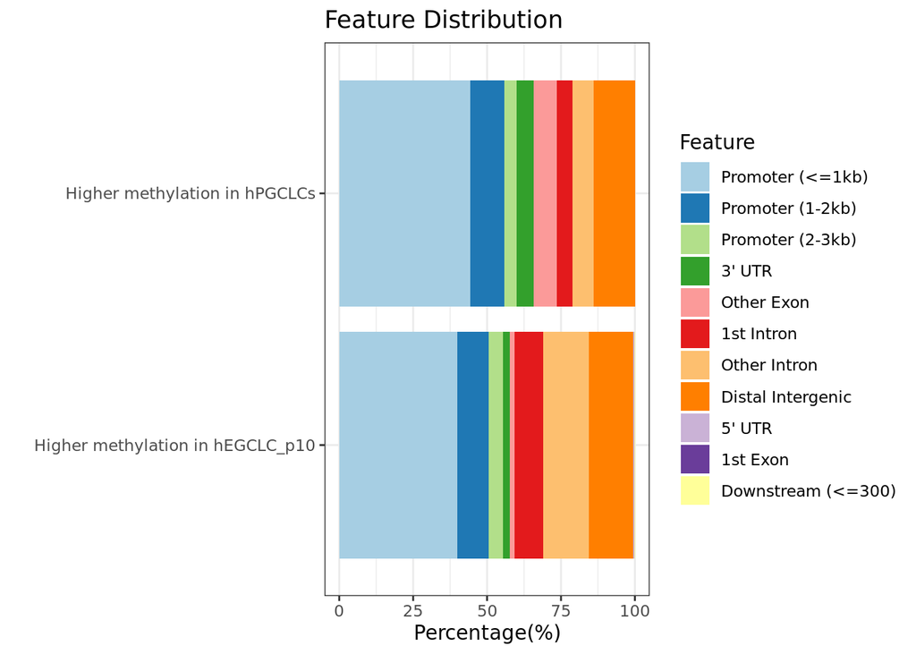

```r
ChIPseeker::plotAnnoBar(peakAnnoList)
```

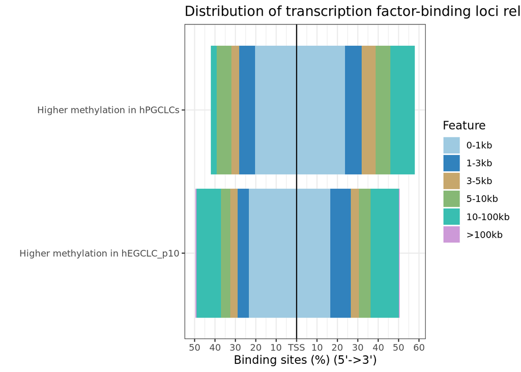

```r
ChIPseeker::plotDistToTSS(peakAnnoList)
```

Given a list of gene set, `compareCluster` function will compute profiles of each gene cluster.

```r
genes = lapply(peakAnnoList, function(i) unique(as.data.frame(i)$geneId))
names(genes) = sub("_", "\n", names(genes))
```

```r
any(duplicated(genes$`Higher methylation in hPGCLCs`))
```

```
## [1] FALSE
```

```r
any(duplicated(genes$`Higher methylation in hEGCLC_p10`))
```

```
## [1] FALSE
```

There are no duplicated ensembl ids

```r
table(genes$`Higher methylation in hEGCLC_p10` %in% Genes_df$ensembl_gene_id_version)
## < table of extent 0 >
```

```r
genes$`Higher methylation in hEGCLC_p10` [!genes$`Higher methylation in hEGCLC_p10` %in% Genes_df$ensembl_gene_id_version]
## NULL
```

```r
table(genes$`Higher methylation in hPGCLCs`%in% Genes_df$ensembl_gene_id_version)
```

```
##
## FALSE  TRUE
##    34   157
```

```r
DMG_uphPGCLCsvshEGCLC_p10 <- Genes_df[Genes_df$ensembl_gene_id_version %in% genes$`Higher methylation in hPGCLCs`, "entrez_gene_id"]
DMG_uphPGCLCsvshEGCLC_p10 <- na.omit(DMG_uphPGCLCsvshEGCLC_p10[!DMG_uphPGCLCsvshEGCLC_p10 %in% ""])
DMG_downhPGCLCsvshEGCLC_p10 <- Genes_df[Genes_df$ensembl_gene_id_version %in% genes$`Higher methylation in hEGCLC_p10`, "entrez_gene_id"]
DMG_downhPGCLCsvshEGCLC_p10 <- na.omit(DMG_downhPGCLCsvshEGCLC_p10[!DMG_downhPGCLCsvshEGCLC_p10 %in% ""])
```

```r
any(duplicated(DMG_uphPGCLCsvshEGCLC_p10))
```

```
## [1] FALSE
```

```r
any(duplicated(DMG_downhPGCLCsvshEGCLC_p10))
```

```
## [1] FALSE
```

```r
genes$`Higher methylation in hPGCLCs` <- DMG_uphPGCLCsvshEGCLC_p10
genes$`Higher methylation in hEGCLC_p10` <- DMG_downhPGCLCsvshEGCLC_p10
```

```r
compKEGG <- compareCluster(geneCluster   = genes,
                         fun           = "enrichKEGG",
                         organism="hsa",
                         pvalueCutoff  = 0.05,
                         pAdjustMethod = "BH",
                         universe = GeneUniverse_entrezid)
```

There are no significant terms (They have Padj>0.05)

```r
#dotplot(compKEGG, showCategory = 15, title = "KEGG Pathway Enrichment Analysis")
```

```r
compGO <- compareCluster(geneCluster   = genes,
                         fun           = "enrichGO",
                         keyType = "ENTREZID",
                         pvalueCutoff  = 0.05,
                         pAdjustMethod = "BH",
                         OrgDb='org.Hs.eg.db',
                         universe=GeneUniverse_entrezid,
                         ont = "ALL")
```

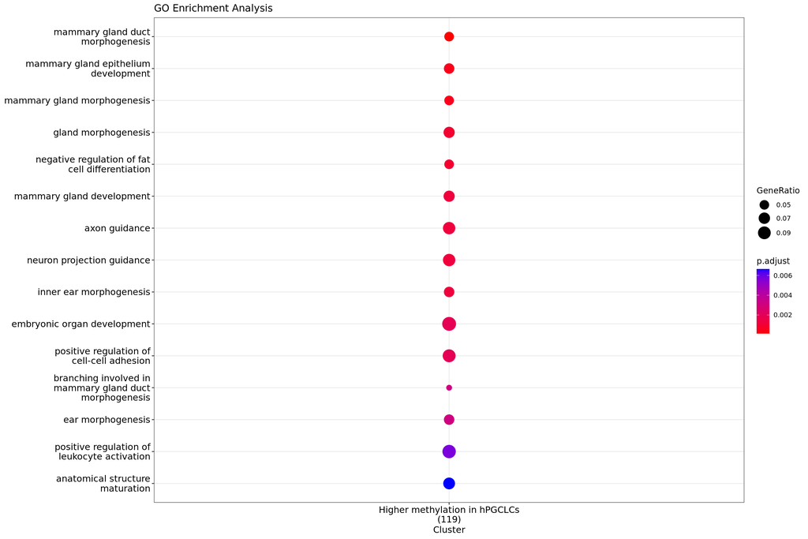

```r
dotplot(compGO, showCategory = 15, title = "GO Enrichment Analysis")
```

A new `DMRs_annotated` object is created in which annotation from `ChIPseeker` is added.

```r
DMRs_annotated <- DMRs_GRanges

mcols(DMRs_annotated$hEGCLCs_p10vshPGCLCs)$ChipSeekerAnn <- NA
mcols(DMRs_annotated$hEGCLCs_p10vshPGCLCs)$ChipSeekerDistanceToTss <- NA
mcols(DMRs_annotated$hEGCLCs_p10vshPGCLCs)$ChipSeekerGeneId <- NA

m <- findOverlaps(DMRs_annotated$hEGCLCs_p10vshPGCLCs, peakAnnoList[["Higher methylation in hPGCLCs"]]@anno)
mcols(DMRs_annotated$hEGCLCs_p10vshPGCLCs)[queryHits(m), "ChipSeekerAnn"] <- mcols(peakAnnoList[["Higher methylation in hPGCLCs"]]@anno)[subjectHits(m), "annotation"]
mcols(DMRs_annotated$hEGCLCs_p10vshPGCLCs)[queryHits(m), "ChipSeekerDistanceToTss"] <- mcols(peakAnnoList[["Higher methylation in hPGCLCs"]]@anno)[subjectHits(m), "distanceToTSS"]
mcols(DMRs_annotated$hEGCLCs_p10vshPGCLCs)[queryHits(m), "ChipSeekerGeneId"] <- mcols(peakAnnoList[["Higher methylation in hPGCLCs"]]@anno)[subjectHits(m), "geneId"]

m <- findOverlaps(DMRs_annotated$hEGCLCs_p10vshPGCLCs, peakAnnoList[["Higher methylation in hEGCLC_p10"]]@anno)
mcols(DMRs_annotated$hEGCLCs_p10vshPGCLCs)[queryHits(m), "ChipSeekerAnn"] <- mcols(peakAnnoList[["Higher methylation in hEGCLC_p10"]]@anno)[subjectHits(m), "annotation"]
mcols(DMRs_annotated$hEGCLCs_p10vshPGCLCs)[queryHits(m), "ChipSeekerDistanceToTss"] <- mcols(peakAnnoList[["Higher methylation in hEGCLC_p10"]]@anno)[subjectHits(m), "distanceToTSS"]
mcols(DMRs_annotated$hEGCLCs_p10vshPGCLCs)[queryHits(m), "ChipSeekerGeneId"] <- mcols(peakAnnoList[["Higher methylation in hEGCLC_p10"]]@anno)[subjectHits(m), "geneId"]
```

Adding entrez gene id, gene symbol and gene information

```r
DMRs_annotated$hEGCLCs_p10vshPGCLCs <- as.data.frame(DMRs_annotated$hEGCLCs_p10vshPGCLCs)
DMRs_annotated$hEGCLCs_p10vshPGCLCs <- dplyr::left_join(DMRs_annotated$hEGCLCs_p10vshPGCLCs, Genes_df, by=c('ChipSeekerGeneId' = 'ensembl_gene_id_version'))
```

```r
DMRs_annotated$hEGCLCs_p10vshPGCLCs[!is.na(DMRs_annotated$hEGCLCs_p10vshPGCLCs$hgnc_symbol),] %>% select(-c("ChipSeekerDistanceToTss", "ChipSeekerGeneId", "ensembl_gene_id", "entrez_gene_id")) %>% distinct() %>%
    datatable(class = 'hover', rownames = FALSE, caption="DMRs - hEGCLCs_p10vshPGCLCs", extension='Buttons', escape = FALSE,
              options = list(pageLength=20, dom='Bfrtip', autoWidth=TRUE,
                             buttons=list(c('csv', 'excel'))))
```

| seqnames | start | end | width | strand | length | nCG | meanMethy1 | meanMethy2 | diff.Methy | areaStat | ChipSeekerAnn | hgnc_symbol | gene_biotype |
| --- | --- | --- | --- | --- | --- | --- | --- | --- | --- | --- | --- | --- | --- |
| chr11 | 315102 | 317087 | 1986 | * | 1987 | 99 | 0.7570536565625884 | 0.1747042170140741 | 0.5823494395485143 | 6591.137412968452 | Promoter (<=1kb) | IFITM1 | protein_coding |
| chr8 | 38973989 | 38975246 | 1258 | * | 1259 | 95 | 0.1121879650852303 | 0.7703806839078637 | -0.6581927188226334 | -6429.974650986484 | Promoter (<=1kb) | HTRA4 | protein_coding |
| chr11 | 64368176 | 64371387 | 3212 | * | 3213 | 167 | 0.3228251326758195 | 0.8980218093004275 | -0.5751966766246079 | -5854.886649597362 | Promoter (<=1kb) | MIR1237 | miRNA |
| chr6 | 144007860 | 144008708 | 849 | * | 850 | 111 | 0.1825421130048052 | 0.4863595340411631 | -0.3038174210363579 | -4231.963965070141 | Promoter (<=1kb) | PLAGL1 | protein_coding |
| chr5 | 172669729 | 172670381 | 653 | * | 654 | 89 | 0.233007224630159 | 0.736730631606076 | -0.503723406975917 | -4145.026780794297 | Exon (ENST00000369800.6/ENSG00000214357.9, exon 2 of 5) | MIR5003 | miRNA |
| chr19 | 45396154 | 45397055 | 902 | * | 903 | 99 | 0.05890417758369892 | 0.510461364016309 | -0.4515571864326101 | -3986.523960925169 | Promoter (2-3kb) | PPP1R13L | protein_coding |
| chr1 | 6470842 | 6471752 | 911 | * | 912 | 85 | 0.08557386546658612 | 0.5074392125573347 | -0.4218653470907486 | -3410.778490532185 | Promoter (<=1kb) | PLEKHG5 | protein_coding |
| chr1 | 248847303 | 248848291 | 989 | * | 990 | 116 | 0.492565124042818 | 0.9381227478661032 | -0.4455576238232851 | -3105.780571264444 | Exon (ENST00000306562.8/ENSG00000171161.13, exon 4 of 4) | ZNF692 | protein_coding |
| chr11 | 66568068 | 66568850 | 783 | * | 784 | 80 | 0.2774003544811813 | 0.6603557955411675 | -0.3829554410599862 | -2964.202233617351 | Promoter (<=1kb) | CTSF | protein_coding |
| chr13 | 113022412 | 113023734 | 1323 | * | 1324 | 57 | 0.8369121464116862 | 0.2112025162749807 | 0.6257096301367056 | 2905.827579287253 | Promoter (<=1kb) | MCF2L | protein_coding |

[output cut: 2654 more lines]

```r
saveRDS(DMRs_annotated, paste0(OutputFolder, '/', 'DMRsAnnotated3.rds'))
```

## 4.4 hEGCLCs_p5 vs hEGCLCs_p10

### 4.4.1 Genetic annotation and visualization with **`ChIPseeker`**

DMRs are now annotated to their associated genes and genomic regions using the `annotatePeaks` function of the `ChIPseeker`R package, using a TxDb object. The [`GenomicFeatures`](https://bioconductor.org/packages/devel/bioc/vignettes/GenomicFeatures/inst/doc/GenomicFeatures.html) package uses `TxDb` objects to store transcript metadata. This class maps the 5’ and 3’ untranslated regions (UTRs), protein coding sequences (CDSs) and exons for a set of mRNA transcripts to their associated genome. All `TxDb` objects are backed by a SQLite database that manages genomic locations and the relationships between pre-processed mRNA transcripts, exons, protein coding sequences, and their related gene identifiers.

**TxDb created by us**

```r
peakAnnoList <- lapply(list("Higher methylation in hEGCLCs_p5" = DMRs_GRanges$hEGCLCs_p10vshEGCLCs_p5[DMRs_GRanges$hEGCLCs_p10vshEGCLCs_p5$diff.Methy<0,], "Higher methylation in hEGCLCs_p10" = DMRs_GRanges$hEGCLCs_p10vshEGCLCs_p5[DMRs_GRanges$hEGCLCs_p10vshEGCLCs_p5$diff.Methy>0,]), annotatePeak, TxDb=txdb_v35, tssRegion=c(-3000, 3000), verbose=FALSE)
```

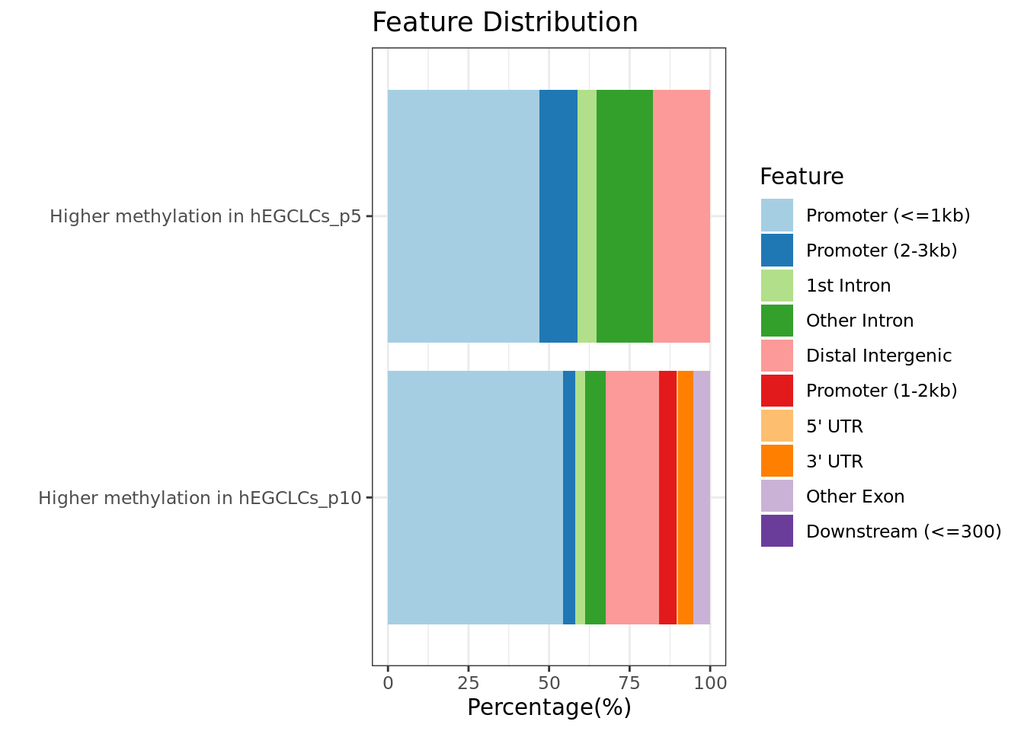

```r
ChIPseeker::plotAnnoBar(peakAnnoList)
```

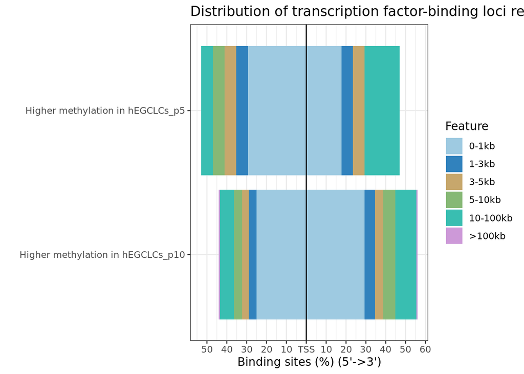

```r
ChIPseeker::plotDistToTSS(peakAnnoList)
```

Given a list of gene set, `compareCluster` function will compute profiles of each gene cluster.

```r
genes = lapply(peakAnnoList, function(i) unique(as.data.frame(i)$geneId))
names(genes) = sub("_", "\n", names(genes))
```

```r
any(duplicated(genes$`Higher methylation in hEGCLCs_p5`))
```

```
## [1] FALSE
```

```r
any(duplicated(genes$`Higher methylation in hEGCLCs_p10`))
```

```
## [1] FALSE
```

There are no duplicated ensembl ids

```r
table(genes$`Higher methylation in hEGCLCs_p10` %in% Genes_df$ensembl_gene_id_version)
## < table of extent 0 >
```

```r
genes$`Higher methylation in hEGCLCs_p10` [!genes$`Higher methylation in hEGCLCs_p10` %in% Genes_df$ensembl_gene_id_version]
## NULL
```

```r
table(genes$`Higher methylation in hEGCLCs_p5`%in% Genes_df$ensembl_gene_id_version)
## < table of extent 0 >
```

```r
DMG_uphEGCLCs_p5vshEGCLCs_p10 <- Genes_df[Genes_df$ensembl_gene_id_version %in% genes$`Higher methylation in hEGCLCs_p5`, "entrez_gene_id"]
DMG_uphEGCLCs_p5vshEGCLCs_p10 <- na.omit(DMG_uphEGCLCs_p5vshEGCLCs_p10[!DMG_uphEGCLCs_p5vshEGCLCs_p10 %in% ""])
DMG_downhEGCLCs_p5vshEGCLCs_p10 <- Genes_df[Genes_df$ensembl_gene_id_version %in% genes$`Higher methylation in hEGCLCs_p10`, "entrez_gene_id"]
DMG_downhEGCLCs_p5vshEGCLCs_p10 <- na.omit(DMG_downhEGCLCs_p5vshEGCLCs_p10[!DMG_downhEGCLCs_p5vshEGCLCs_p10 %in% ""])
```

```r
any(duplicated(DMG_uphEGCLCs_p5vshEGCLCs_p10))
```

```
## [1] FALSE
```

```r
any(duplicated(DMG_downhEGCLCs_p5vshEGCLCs_p10))
```

```
## [1] FALSE
```

```r
genes$`Higher methylation in hEGCLCs_p5` <- DMG_uphEGCLCs_p5vshEGCLCs_p10
genes$`Higher methylation in hEGCLCs_p10` <- DMG_downhEGCLCs_p5vshEGCLCs_p10
```

```r
compKEGG <- compareCluster(geneCluster   = genes,
                         fun           = "enrichKEGG",
                         organism="hsa",
                         pvalueCutoff  = 0.05,
                         pAdjustMethod = "BH",
                         universe = GeneUniverse_entrezid)
```

There are no significant terms (They have Padj>0.05)

```r
#dotplot(compKEGG, showCategory = 15, title = "KEGG Pathway Enrichment Analysis")
```

```r
compGO <- compareCluster(geneCluster   = genes,
                         fun           = "enrichGO",
                         keyType = "ENTREZID",
                         pvalueCutoff  = 0.05,
                         pAdjustMethod = "BH",
                         OrgDb='org.Hs.eg.db',
                         universe=GeneUniverse_entrezid,
                         ont = "ALL")
```

```r
#dotplot(compGO, showCategory = 15, title = "GO Enrichment Analysis")
```

A new `DMRs_annotated` object is created in which annotation from `ChIPseeker` is added.

```r
DMRs_annotated <- DMRs_GRanges

mcols(DMRs_annotated$hEGCLCs_p10vshEGCLCs_p5)$ChipSeekerAnn <- NA
mcols(DMRs_annotated$hEGCLCs_p10vshEGCLCs_p5)$ChipSeekerDistanceToTss <- NA
mcols(DMRs_annotated$hEGCLCs_p10vshEGCLCs_p5)$ChipSeekerGeneId <- NA

m <- findOverlaps(DMRs_annotated$hEGCLCs_p10vshEGCLCs_p5, peakAnnoList[["Higher methylation in hEGCLCs_p5"]]@anno)
mcols(DMRs_annotated$hEGCLCs_p10vshEGCLCs_p5)[queryHits(m), "ChipSeekerAnn"] <- mcols(peakAnnoList[["Higher methylation in hEGCLCs_p5"]]@anno)[subjectHits(m), "annotation"]
mcols(DMRs_annotated$hEGCLCs_p10vshEGCLCs_p5)[queryHits(m), "ChipSeekerDistanceToTss"] <- mcols(peakAnnoList[["Higher methylation in hEGCLCs_p5"]]@anno)[subjectHits(m), "distanceToTSS"]
mcols(DMRs_annotated$hEGCLCs_p10vshEGCLCs_p5)[queryHits(m), "ChipSeekerGeneId"] <- mcols(peakAnnoList[["Higher methylation in hEGCLCs_p5"]]@anno)[subjectHits(m), "geneId"]

m <- findOverlaps(DMRs_annotated$hEGCLCs_p10vshEGCLCs_p5, peakAnnoList[["Higher methylation in hEGCLCs_p10"]]@anno)
mcols(DMRs_annotated$hEGCLCs_p10vshEGCLCs_p5)[queryHits(m), "ChipSeekerAnn"] <- mcols(peakAnnoList[["Higher methylation in hEGCLCs_p10"]]@anno)[subjectHits(m), "annotation"]
mcols(DMRs_annotated$hEGCLCs_p10vshEGCLCs_p5)[queryHits(m), "ChipSeekerDistanceToTss"] <- mcols(peakAnnoList[["Higher methylation in hEGCLCs_p10"]]@anno)[subjectHits(m), "distanceToTSS"]
mcols(DMRs_annotated$hEGCLCs_p10vshEGCLCs_p5)[queryHits(m), "ChipSeekerGeneId"] <- mcols(peakAnnoList[["Higher methylation in hEGCLCs_p10"]]@anno)[subjectHits(m), "geneId"]
```

Adding entrez gene id, gene symbol and gene information

```r
DMRs_annotated$hEGCLCs_p10vshEGCLCs_p5 <- as.data.frame(DMRs_annotated$hEGCLCs_p10vshEGCLCs_p5)
DMRs_annotated$hEGCLCs_p10vshEGCLCs_p5 <- dplyr::left_join(DMRs_annotated$hEGCLCs_p10vshEGCLCs_p5, Genes_df, by=c('ChipSeekerGeneId' = 'ensembl_gene_id_version'))
```

```r
DMRs_annotated$hEGCLCs_p10vshEGCLCs_p5[!is.na(DMRs_annotated$hEGCLCs_p10vshEGCLCs_p5$hgnc_symbol),] %>% select(-c("ChipSeekerDistanceToTss", "ChipSeekerGeneId", "ensembl_gene_id", "entrez_gene_id")) %>% distinct() %>%
    datatable(class = 'hover', rownames = FALSE, caption="DMRs - hEGCLCs_p10vshEGCLCs_p5", extension='Buttons', escape = FALSE,
              options = list(pageLength=20, dom='Bfrtip', autoWidth=TRUE,
                             buttons=list(c('csv', 'excel'))))
```

| seqnames | start | end | width | strand | length | nCG | meanMethy1 | meanMethy2 | diff.Methy | areaStat | ChipSeekerAnn | hgnc_symbol | gene_biotype |
| --- | --- | --- | --- | --- | --- | --- | --- | --- | --- | --- | --- | --- | --- |
| chr11 | 315262 | 317087 | 1826 | * | 1827 | 96 | 0.7580202747357053 | 0.1747441609934633 | 0.583276113742242 | 7727.641056132367 | Promoter (<=1kb) | IFITM1 | protein_coding |
| chrX | 145817367 | 145818886 | 1520 | * | 1521 | 113 | 0.8948262462130645 | 0.361900566357356 | 0.5329256798557085 | 5318.033817619822 | Promoter (<=1kb) | SLITRK2 | protein_coding |
| chr6 | 88047370 | 88048325 | 956 | * | 957 | 82 | 0.955415190945943 | 0.413681493161804 | 0.5417336977841389 | 4946.065851838331 | Promoter (<=1kb) | SPACA1 | protein_coding |
| chr5 | 42950443 | 42951608 | 1166 | * | 1167 | 81 | 0.8985018632554395 | 0.414978805865339 | 0.4835230573901004 | 4678.37049713072 | Distal Intergenic | PRELID3BP7 | processed_pseudogene |
| chr1 | 247517862 | 247518699 | 838 | * | 839 | 78 | 0.839635603171935 | 0.3161857978903177 | 0.5234498052816172 | 4424.044014366027 | Promoter (<=1kb) | GCSAML | protein_coding |
| chr19 | 40213605 | 40214187 | 583 | * | 584 | 78 | 0.9075030842998282 | 0.4448304451222708 | 0.4626726391775574 | 4343.79520255132 | 3' UTR | TTC9B | protein_coding |
| chr19 | 291694 | 292215 | 522 | * | 523 | 58 | 0.8054613880946714 | 0.2500171010305499 | 0.5554442870641214 | 4157.25021567629 | Promoter (<=1kb) | PLPP2 | protein_coding |
| chr1 | 1439273 | 1440113 | 841 | * | 842 | 80 | 0.9417119653358159 | 0.501566086960017 | 0.4401458783757989 | 3938.172824586674 | 3' UTR | VWA1 | protein_coding |
| chr16 | 31224164 | 31224815 | 652 | * | 653 | 76 | 0.8770922359294137 | 0.3569392381288418 | 0.5201529978005719 | 3791.629831875438 | 3' UTR | PYDC1 | protein_coding |
| chr4 | 154781020 | 154782297 | 1278 | * | 1279 | 99 | 0.6150329487944162 | 0.1882342220007042 | 0.426798726793712 | 3772.820423210021 | Promoter (<=1kb) | RBM46 | protein_coding |

[output cut: 579 more lines]

```r
saveRDS(DMRs_annotated, paste0(OutputFolder, '/', 'DMRsAnnotated4.rds'))
```

# 5. Saving DMRs with annotation and Session Info

```r
saveRDS(Genes_df, paste0(OutputFolder, '/', 'GeneUniverse.rds'))
saveRDS(DMRs_annotated, paste0(OutputFolder, '/', 'DMRsAnnotated_final.rds'))
```

```r
SessionInfo <- sessionInfo()
Date <- date()
```

```r
Date
```

```
## [1] "Tue Aug 19 12:31:42 2025"
```

```r
SessionInfo
```